# CO2 Emissions

Khanh Ngo

## Introduction

In this lab we will learn how to use R to graph and summarize a data set.

The data set consists of values of CO$_2$ emissions (in metric tons/person) for different countries in the years between 1960 and 2014.

Your goal is to be able to make plots and compute numerical summaries that will help you describe the distribution of CO$_2$ emissions among these countries.

## Data science methodology

**1. Problem understanding** **2. Analytic approach** 3. Data collection 4. Data preparation **5. Visualize** 6. Model **7. Evaluation** **8. Communicate**

## The problem

1. How are CO$_2$ emissions (in metric tons/person) distributed over different countries in 2010? Are there any countries with very high emissions?
2. How do CO$_2$ emissions in 2010 compare to CO$_2$ emissions in 1960?

## Analytic approach

We will use graphs and numerical summaries to characterize the distribution of CO$_2$ emissions in 2010 and to compare distributions between 1960 and 2010.

## 1. Import libraries

This lab will use the library `ggplot2` to explore our data.

```r
library(tidyverse)
```

## 2. Load the data

You should have a csv file called CO2EmissionsCountries1960to2014.csv saved somewhere where you can access the file.

To load the file, run the cell below. You will need to change the path to the file.

```r
df = read.csv('~/my-portfolio/co2-emissions/CO2EmissionsCountries1960to2014.csv')
```

## 3. Look at the raw data

It is often useful to look at the head of the data frame. This will show you the first few values from each column of the data frame. This helps to give you a sense of what variables are present in the data set and what kinds of values they take on.

```r
head(df)
```

```
##           Country.Name Country.Code                         Indicator.Name
## 1                Aruba          ABW CO2 emissions (metric tons per capita)
## 2          Afghanistan          AFG CO2 emissions (metric tons per capita)
## 3               Angola          AGO CO2 emissions (metric tons per capita)
## 4              Albania          ALB CO2 emissions (metric tons per capita)
## 5              Andorra          AND CO2 emissions (metric tons per capita)
## 6 United Arab Emirates          ARE CO2 emissions (metric tons per capita)
##   Indicator.Code     X1960      X1961      X1962      X1963      X1964
## 1 EN.ATM.CO2E.PC        NA         NA         NA         NA         NA
## 2 EN.ATM.CO2E.PC 0.0460599 0.05360430 0.07376479 0.07423269 0.08629245
## 3 EN.ATM.CO2E.PC 0.0974716 0.07903808 0.20128908 0.19253474 0.20100336
## 4 EN.ATM.CO2E.PC 1.2581949 1.37418605 1.43995596 1.18168114 1.11174196
## 5 EN.ATM.CO2E.PC        NA         NA         NA         NA         NA
## 6 EN.ATM.CO2E.PC 0.1187577 0.10883674 0.16301835 0.17522259 0.13235496
##       X1965     X1966     X1967     X1968        X1969      X1970      X1971
```

[output cut: 55 more lines]

### **Question 3.1**. Use `names(df)` to determine the variables in your data set.

```r
names(df)
```

```
##  [1] "Country.Name"   "Country.Code"   "Indicator.Name" "Indicator.Code"
##  [5] "X1960"          "X1961"          "X1962"          "X1963"
##  [9] "X1964"          "X1965"          "X1966"          "X1967"
## [13] "X1968"          "X1969"          "X1970"          "X1971"
## [17] "X1972"          "X1973"          "X1974"          "X1975"
## [21] "X1976"          "X1977"          "X1978"          "X1979"
## [25] "X1980"          "X1981"          "X1982"          "X1983"
## [29] "X1984"          "X1985"          "X1986"          "X1987"
## [33] "X1988"          "X1989"          "X1990"          "X1991"
## [37] "X1992"          "X1993"          "X1994"          "X1995"
## [41] "X1996"          "X1997"          "X1998"          "X1999"
## [45] "X2000"          "X2001"          "X2002"          "X2003"
## [49] "X2004"          "X2005"          "X2006"          "X2007"
## [53] "X2008"          "X2009"          "X2010"          "X2011"
## [57] "X2012"          "X2013"          "X2014"
```

The columns of interest in the data set are the Country Name, Country Code (which is redundant with Country Name), and the CO$_2$ emissions for many years. The indicator name tells you what is measured in each year.

### **Question 3.2**. For each variable, determine whether it is numerical or categorical.

We can use the `head` of the data frame to determine the types of variables by looking at the label beneath each name.

```r
head(df)
```

```
##           Country.Name Country.Code                         Indicator.Name
## 1                Aruba          ABW CO2 emissions (metric tons per capita)
## 2          Afghanistan          AFG CO2 emissions (metric tons per capita)
## 3               Angola          AGO CO2 emissions (metric tons per capita)
## 4              Albania          ALB CO2 emissions (metric tons per capita)
## 5              Andorra          AND CO2 emissions (metric tons per capita)
## 6 United Arab Emirates          ARE CO2 emissions (metric tons per capita)
##   Indicator.Code     X1960      X1961      X1962      X1963      X1964
## 1 EN.ATM.CO2E.PC        NA         NA         NA         NA         NA
## 2 EN.ATM.CO2E.PC 0.0460599 0.05360430 0.07376479 0.07423269 0.08629245
## 3 EN.ATM.CO2E.PC 0.0974716 0.07903808 0.20128908 0.19253474 0.20100336
## 4 EN.ATM.CO2E.PC 1.2581949 1.37418605 1.43995596 1.18168114 1.11174196
## 5 EN.ATM.CO2E.PC        NA         NA         NA         NA         NA
## 6 EN.ATM.CO2E.PC 0.1187577 0.10883674 0.16301835 0.17522259 0.13235496
##       X1965     X1966     X1967     X1968        X1969      X1970      X1971
```

[output cut: 55 more lines]

We can also use the `str` function to determine the types of variables:

```r
str(df)
```

```
## 'data.frame':    218 obs. of  59 variables:
##  $ Country.Name  : chr  "Aruba" "Afghanistan" "Angola" "Albania" ...
##  $ Country.Code  : chr  "ABW" "AFG" "AGO" "ALB" ...
##  $ Indicator.Name: chr  "CO2 emissions (metric tons per capita)" "CO2 emissions (metric tons per capita)" "CO2 emissions (metric tons per capita)" "CO2 emissions (metric tons per capita)" ...
##  $ Indicator.Code: chr  "EN.ATM.CO2E.PC" "EN.ATM.CO2E.PC" "EN.ATM.CO2E.PC" "EN.ATM.CO2E.PC" ...
##  $ X1960         : num  NA 0.0461 0.0975 1.2582 NA ...
##  $ X1961         : num  NA 0.0536 0.079 1.3742 NA ...
##  $ X1962         : num  NA 0.0738 0.2013 1.44 NA ...
##  $ X1963         : num  NA 0.0742 0.1925 1.1817 NA ...
##  $ X1964         : num  NA 0.0863 0.201 1.1117 NA ...
##  $ X1965         : num  NA 0.101 0.192 1.166 NA ...
##  $ X1966         : num  NA 0.108 0.246 1.333 NA ...
##  $ X1967         : num  NA 0.124 0.155 1.364 NA ...
##  $ X1968         : num  NA 0.115 0.256 1.52 NA ...
##  $ X1969         : num  NA 0.0868 0.4196 1.559 NA ...
```

[output cut: 45 more lines]

Most significantly, CO$_2$ emission at each year is a number and it makes sense to do arithmetic with the values, so it is a numerical variable.

### **Question 3.3**. Look at the raw CO$_2$ data for all countries in 2010. Can you tell from looking at the table of data values what the shape of the CO$_2$ emission distribution looks like?

```r
#To look at the entire data set, we can type the name of our data frame.
#To look at one column, type df$Name of the column

df$X2010
```

```
##   [1] 24.67052887  0.29383699  1.24340559  1.57857358  6.12259470 19.44369027
##   [7]  4.55849961  1.46562189          NA  5.53956751 17.74084505  8.07113180
##  [13]  3.38822588  0.02426003 10.17146522  0.55328326  0.12571725  0.39393670
##  [19]  5.96490021 23.58548090  4.58334350  5.71613483  6.64269666  1.67610569
##  [25]  9.34712241  1.53287064  2.13293757  5.28599737 21.10594553  0.67026322
##  [31]  2.32592440  0.05935091 15.72316700  4.98342894          NA  4.25171517
##  [37]  6.56052001  0.34151203  0.33951502  0.03131455  0.45140611  1.65892308
##  [43]  0.23394211  1.10947801  1.66517530  3.38612744          NA 10.04168844
##  [49]  6.92790356 10.65257862  9.27963401  0.60747157  1.95053192  8.40721667
##  [55]  2.12395866  3.29970369  2.44136176  2.41019138  0.11692068  5.81641637
##  [61] 13.59968907  0.07509386 11.57528165  1.41997907  5.42898086 12.99122554
##  [67]  1.09709890  2.93322440  7.85783649  1.60839888  0.40616281 14.03202868
##  [73]  0.24120150  0.25571389  0.15319626  4.91964286  7.54018387  2.48724171
##  [79] 11.66377295  0.79729286          NA  2.30367581  5.79112653  0.97326920
##  [85]  4.56613105  0.21269415  5.02231165  1.76790788          NA  1.39700891
```

[output cut: 22 more lines]

If we attach the data frame, then we can call the variables directly.

```r
attach(df)

X2010
```

```
##   [1] 24.67052887  0.29383699  1.24340559  1.57857358  6.12259470 19.44369027
##   [7]  4.55849961  1.46562189          NA  5.53956751 17.74084505  8.07113180
##  [13]  3.38822588  0.02426003 10.17146522  0.55328326  0.12571725  0.39393670
##  [19]  5.96490021 23.58548090  4.58334350  5.71613483  6.64269666  1.67610569
##  [25]  9.34712241  1.53287064  2.13293757  5.28599737 21.10594553  0.67026322
##  [31]  2.32592440  0.05935091 15.72316700  4.98342894          NA  4.25171517
##  [37]  6.56052001  0.34151203  0.33951502  0.03131455  0.45140611  1.65892308
##  [43]  0.23394211  1.10947801  1.66517530  3.38612744          NA 10.04168844
##  [49]  6.92790356 10.65257862  9.27963401  0.60747157  1.95053192  8.40721667
##  [55]  2.12395866  3.29970369  2.44136176  2.41019138  0.11692068  5.81641637
##  [61] 13.59968907  0.07509386 11.57528165  1.41997907  5.42898086 12.99122554
##  [67]  1.09709890  2.93322440  7.85783649  1.60839888  0.40616281 14.03202868
##  [73]  0.24120150  0.25571389  0.15319626  4.91964286  7.54018387  2.48724171
##  [79] 11.66377295  0.79729286          NA  2.30367581  5.79112653  0.97326920
##  [85]  4.56613105  0.21269415  5.02231165  1.76790788          NA  1.39700891
```

[output cut: 22 more lines]

It is difficult to understand the shape of the distribution just by looking at the data table. There are clearly a few large values and many smaller values, but the exact shape of the distribution is not easy to visualize.

We can do better using graphs to visualize the distribution.

## 4. Graphing the distribution

### **Question 4.1**. Why is a histogram an appropriate graph to use to visualize the CO$_2$ distribution?

CO$_2$ emission is a continous numerical variable and our data set is not small (n = 218), so a histogram is an appropriate graph to use.

### **Question 4.2**. Construct a histogram of the CO$_2$ emission data from 2010 using 20 bins and describe the distribution.

Your histogram should have the axes labeled.

Be sure to describe all relevant features of the histogram.

We can use the `hist` function from the base R package

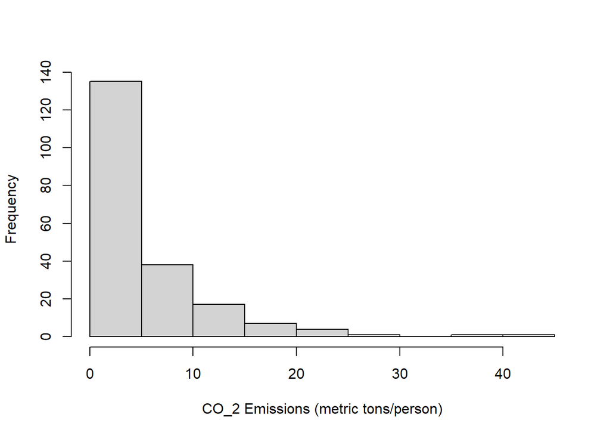

```r
hist(X2010, xlab = "CO_2 Emissions (metric tons/person)",main = " ")
```

We can also use `ggplot2` to make the histogram. This has more complicated syntax, but it can make very nice graphs.

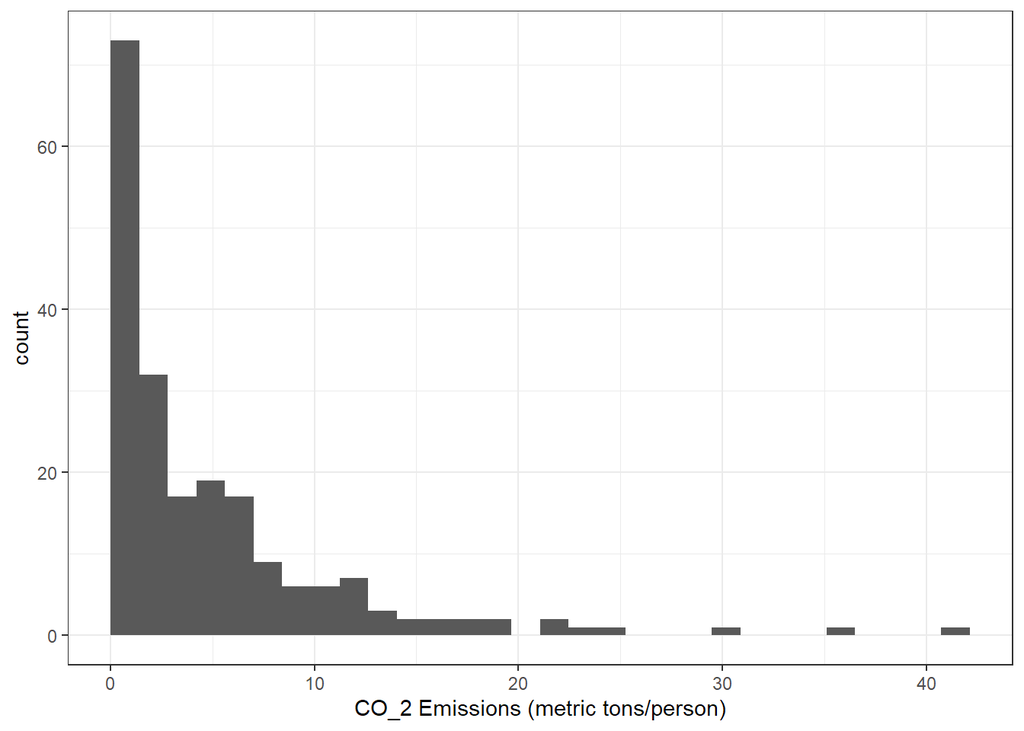

```r
ggplot(df, aes(x = X2010)) +
  geom_histogram(boundary = 0) +
  xlab("CO_2 Emissions (metric tons/person)") +
  theme_bw()
```

We can also plot the histogram on a density scale:

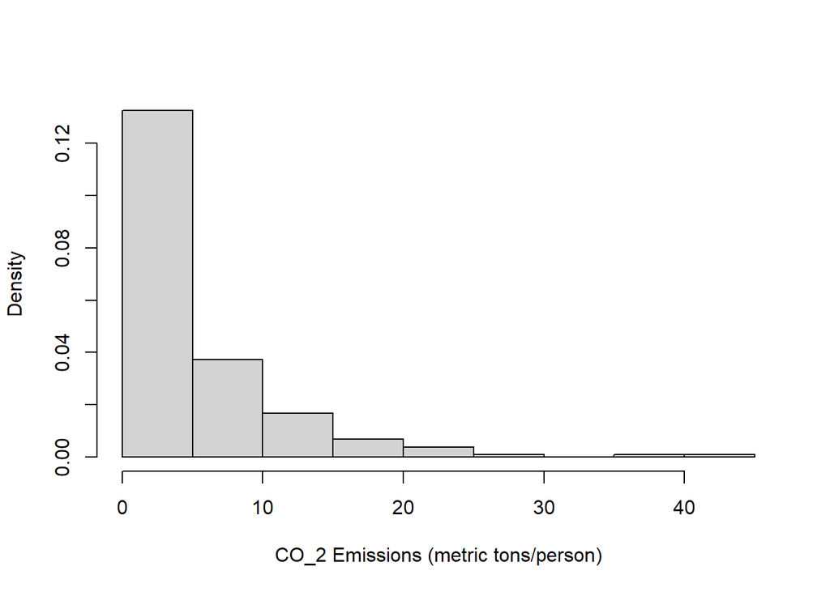

```r
hist(X2010, freq = FALSE, xlab = "CO_2 Emissions (metric tons/person)", main = " ")
```

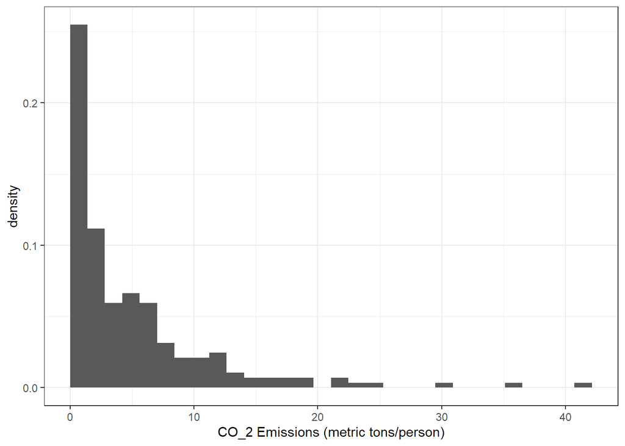

```r
ggplot(df, aes(x = X2010, y = ..density..)) +
  geom_histogram(boundary = 0) +
  xlab("CO_2 Emissions (metric tons/person)") +
  theme_bw()
```

The histogram is skewed to the right, or positively skewed. This is consistent with our initial impression that there are many small values and a few large values of emissions.

There are several countries at the upper end of the range of emissions that are potential outliers.

The distribution has one main peak and is therefore unimodal.

### **Question 4.3**. Construct histograms of the CO$_2$ emission data in 2010 with different numbers of bins. Does your impression of the distribution change with different numbers of bins?

Try changing the number of breaks first.

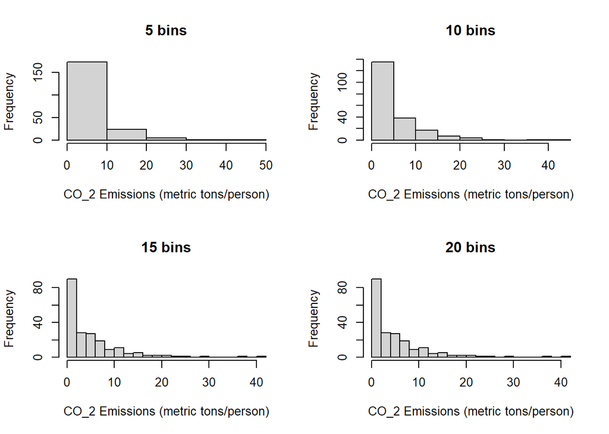

```r
#Set up the plot with 4 panels
par(mfrow = c(2,2))

#Use 5 bins
hist(X2010, breaks = 5, xlab = "CO_2 Emissions (metric tons/person)", main = "5 bins")

#Use 10 bins
hist(X2010, breaks = 10, xlab = "CO_2 Emissions (metric tons/person)", main = "10 bins")

#Use 15 bins
hist(X2010, breaks = 15, xlab = "CO_2 Emissions (metric tons/person)", main = "15 bins")

#Use 20 bins
hist(X2010, breaks = 20, xlab = "CO_2 Emissions (metric tons/person)", main = "20 bins")
```

Note that the histograms with 15 and 20 breaks are the same. This is due to the way that the `hist` function treats the argument `breaks` when you only give a number. It may override your suggestion to give you a better graph.

We can control the number of bins by letting `breaks` be a vector of the breakpoints.

First determine the minimum and maximum values of CO$_2$ emissions in 2010 so that we don’t miss any data points.

```r
summary(X2010)
```

```
##     Min.  1st Qu.   Median     Mean  3rd Qu.     Max.     NA's
##  0.02426  0.66676  2.59496  4.92101  6.58073 40.74202       14
```

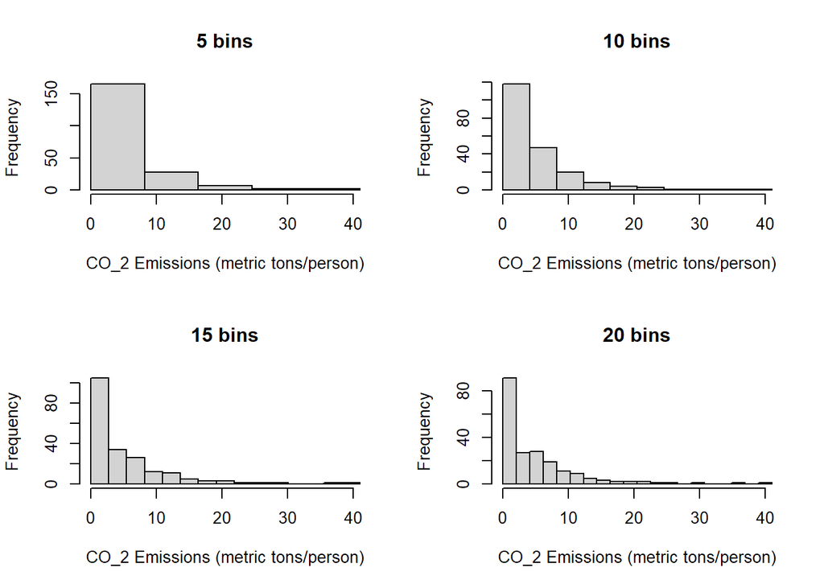

```r
#Set up the plot with 4 panels
par(mfrow = c(2,2))

#Use 5 bins
hist(X2010, breaks = seq(0,41,length.out = 6), xlab = "CO_2 Emissions (metric tons/person)", main = "5 bins")

#Use 10 bins
hist(X2010, breaks = seq(0,41,length.out = 11), xlab = "CO_2 Emissions (metric tons/person)", main = "10 bins")

#Use 15 bins
hist(X2010, breaks = seq(0,41,length.out = 16), xlab = "CO_2 Emissions (metric tons/person)", main = "15 bins")

#Use 20 bins
hist(X2010, breaks = seq(0,41,length.out = 21), xlab = "CO_2 Emissions (metric tons/person)", main = "20 bins")
```

The distribution looks similar using histograms with 10, 15, and 20 bins. The distribution is skewed to the right and there are several potential outliers. The histogram with 5 bins does not let us see some of the detail.

## 5. Numerical summaries

### **Question 5.1**. Review the definitions of the sample mean, median, standard deviation, interquartile range, and 5-number summary of a data set.

Suppose we have a data set consisting of $n$ values $x_1, x_2, \ldots, x_n$.

**Measure of center**

The sample mean is $\displaystyle \bar{x} = \frac{1}{n}\sum_{i = 1}^n x_i$.

The sample median $\tilde{x}$ is the $50^{th}$ percentile. If $n$ is odd, then $\tilde{x}$ is the middle value after the values are ordered. If $n$ is even, then $\tilde{x}$ is the average of the two middle values after the values are ordered.

**Measures of spread**

The sample standard deviation is $\displaystyle s = \sqrt{\frac{1}{n - 1}\sum_{i = 1}^n (x_i - \bar{x})^2}$.

The first quartile is the $25{th}$ percentile and the third quartile is the $75{th}$ percentile. The interquartile range is the difference between the $75{th}$ percentile and $25{th}$ percentile.

**5-number summary**

The 5-number summary consists of the 5 numbers: minimum, first quartile, median, third quartile, maximum.

### **Question 5.2**. Use the `summary()` function to compute the sample mean, median, standard deviation, interquartile range, and 5-number summary of the CO$_2$ data set.

```r
summary(df)
```

```
##  Country.Name       Country.Code       Indicator.Name     Indicator.Code
##  Length:218         Length:218         Length:218         Length:218
##  Class :character   Class :character   Class :character   Class :character
##  Mode  :character   Mode  :character   Mode  :character   Mode  :character
##
##
##
##
##      X1960              X1961              X1962              X1963
##  Min.   : 0.00802   Min.   : 0.00789   Min.   : 0.00848   Min.   : 0.00938
##  1st Qu.: 0.14445   1st Qu.: 0.15078   1st Qu.: 0.17168   1st Qu.: 0.17129
##  Median : 0.48039   Median : 0.49723   Median : 0.54799   Median : 0.54540
##  Mean   : 2.07068   Mean   : 2.21660   Mean   : 2.31606   Mean   : 2.94798
##  3rd Qu.: 1.79083   3rd Qu.: 2.15833   3rd Qu.: 2.16916   3rd Qu.: 1.94643
##  Max.   :36.68518   Max.   :36.58378   Max.   :42.24200   Max.   :99.46300
##  NA's   :66         NA's   :65         NA's   :63         NA's   :62
##      X1964             X1965              X1966              X1967
##  Min.   : 0.0116   Min.   : 0.01191   Min.   : 0.01326   Min.   : 0.0118
##  1st Qu.: 0.1835   1st Qu.: 0.20320   1st Qu.: 0.21185   1st Qu.: 0.2100
##  Median : 0.6593   Median : 0.65755   Median : 0.70406   Median : 0.6994
##  Mean   : 3.1126   Mean   : 3.23986   Mean   : 3.23665   Mean   : 3.3043
##  3rd Qu.: 2.1404   3rd Qu.: 2.37521   3rd Qu.: 3.09994   3rd Qu.: 4.0455
##  Max.   :92.8595   Max.   :85.45859   Max.   :78.62712   Max.   :77.5086
##  NA's   :56        NA's   :56         NA's   :56         NA's   :56
##      X1968             X1969               X1970              X1971
##  Min.   :-0.0201   Min.   :  0.01612   Min.   : 0.01229   Min.   : 0.0119
##  1st Qu.: 0.2392   1st Qu.:  0.25015   1st Qu.: 0.31817   1st Qu.: 0.3161
##  Median : 0.8270   Median :  0.82311   Median : 0.92480   Median : 1.0347
##  Mean   : 3.5195   Mean   :  4.25120   Mean   : 4.52894   Mean   : 4.7819
##  3rd Qu.: 4.1746   3rd Qu.:  4.16021   3rd Qu.: 5.16609   3rd Qu.: 5.2407
##  Max.   :75.9753   Max.   :100.69767   Max.   :69.11160   Max.   :76.6415
##  NA's   :56        NA's   :56          NA's   :54         NA's   :53
##      X1972              X1973              X1974              X1975
##  Min.   : 0.01153   Min.   : 0.01117   Min.   : 0.00974   Min.   : 0.00975
##  1st Qu.: 0.31364   1st Qu.: 0.32969   1st Qu.: 0.33729   1st Qu.: 0.33150
##  Median : 1.01947   Median : 1.09820   Median : 1.09737   Median : 1.20875
##  Mean   : 4.83208   Mean   : 5.18048   Mean   : 4.81708   Mean   : 4.66142
##  3rd Qu.: 5.23628   3rd Qu.: 5.80763   3rd Qu.: 5.77026   3rd Qu.: 5.80496
##  Max.   :82.61945   Max.   :87.65265   Max.   :68.23258   Max.   :66.64312
##  NA's   :51         NA's   :51         NA's   :51         NA's   :51
```

[output cut: 65 more lines]

```
##  Min.   : 0.02322   Min.   : 0.02246   Min.   : 0.02426   Min.   : 0.02676
##  1st Qu.: 0.63264   1st Qu.: 0.64362   1st Qu.: 0.66676   1st Qu.: 0.72224
##  Median : 2.53446   Median : 2.65993   Median : 2.59496   Median : 2.63290
##  Mean   : 5.03225   Mean   : 4.80777   Mean   : 4.92101   Mean   : 4.85988
##  3rd Qu.: 7.02987   3rd Qu.: 6.31103   3rd Qu.: 6.58073   3rd Qu.: 6.62682
##  Max.   :46.67214   Max.   :43.51448   Max.   :40.74202   Max.   :41.20565
##  NA's   :14         NA's   :14         NA's   :14         NA's   :14
##      X2012             X2013              X2014
##  Min.   : 0.0303   Min.   : 0.03018   Min.   : 0.04449
##  1st Qu.: 0.7581   1st Qu.: 0.78536   1st Qu.: 0.86887
##  Median : 2.6378   Median : 2.77112   Median : 2.76498
##  Mean   : 5.0300   Mean   : 4.93397   Mean   : 4.97369
##  3rd Qu.: 6.5080   3rd Qu.: 6.31973   3rd Qu.: 6.21894
##  Max.   :44.6179   Max.   :37.78009   Max.   :45.42324
##  NA's   :12        NA's   :12         NA's   :14
```

Compute the standard deviations

```r
apply(df,2,sd,na.rm = TRUE)
```

```
##   Country.Name   Country.Code Indicator.Name Indicator.Code          X1960
##             NA             NA             NA             NA       4.457112
##          X1961          X1962          X1963          X1964          X1965
##       4.683338       5.062040       9.341651       9.352750       9.583044
##          X1966          X1967          X1968          X1969          X1970
##       8.841837       7.918706       7.812391      10.892139      10.118825
##          X1971          X1972          X1973          X1974          X1975
##      10.818917      11.086234      11.772222      10.008236       9.186389
##          X1976          X1977          X1978          X1979          X1980
##       8.721713       8.633703       8.681903       8.580258       7.980351
##          X1981          X1982          X1983          X1984          X1985
##       6.608298       6.156598       5.582151       5.893358       5.939077
##          X1986          X1987          X1988          X1989          X1990
##       5.859522       5.605441       5.769038       6.055253       5.956513
##          X1991          X1992          X1993          X1994          X1995
##       6.034145       6.386811       6.764967       6.657843       6.823589
##          X1996          X1997          X1998          X1999          X2000
##       6.662871       7.023239       6.580987       6.334985       6.794260
##          X2001          X2002          X2003          X2004          X2005
##       6.969592       6.730571       6.781981       6.696982       6.836770
##          X2006          X2007          X2008          X2009          X2010
##       7.006817       6.817247       6.585042       6.253323       6.283470
##          X2011          X2012          X2013          X2014
##       6.205093       6.629599       6.255262       6.540012
```

Compute the interquartile ranges

```r
apply(df,2,IQR,na.rm = TRUE)
```

```
##   Country.Name   Country.Code Indicator.Name Indicator.Code          X1960
##             NA             NA             NA             NA       1.646384
##          X1961          X1962          X1963          X1964          X1965
##       2.007547       1.997476       1.775135       1.956858       2.172009
##          X1966          X1967          X1968          X1969          X1970
##       2.888085       3.835518       3.935344       3.910059       4.847929
##          X1971          X1972          X1973          X1974          X1975
##       4.924586       4.922635       5.477937       5.432972       5.473464
##          X1976          X1977          X1978          X1979          X1980
##       5.234953       6.037060       6.273882       5.742049       5.755422
##          X1981          X1982          X1983          X1984          X1985
##       5.292667       5.361184       5.329422       5.453518       5.727951
##          X1986          X1987          X1988          X1989          X1990
##       5.697900       5.662595       5.910382       6.156406       5.916387
##          X1991          X1992          X1993          X1994          X1995
##       5.844933       6.105471       6.379029       6.036844       6.376160
##          X1996          X1997          X1998          X1999          X2000
##       6.302838       6.170431       6.601602       6.580446       6.526284
##          X2001          X2002          X2003          X2004          X2005
##       6.727229       6.864270       6.765212       6.507102       6.397919
##          X2006          X2007          X2008          X2009          X2010
##       6.388737       6.243086       6.397234       5.667410       5.913965
##          X2011          X2012          X2013          X2014
##       5.904579       5.749912       5.534372       5.350072
```

Focussing on 2010

```r
summary(X2010)
```

```
##     Min.  1st Qu.   Median     Mean  3rd Qu.     Max.     NA's
##  0.02426  0.66676  2.59496  4.92101  6.58073 40.74202       14
```

```r
sd(X2010,na.rm = TRUE)
```

```
## [1] 6.28347
```

```r
IQR(X2010,na.rm = TRUE)
```

```
## [1] 5.913965
```

We can use the pipe operator `%>%` together with other operations to transform a data frame.

```r
df_spread = df %>%
  summarize(std_dev = sd(X2010,na.rm = TRUE), iqr = IQR(X2010,na.rm = TRUE))

df_spread
```

```
##   std_dev      iqr
## 1 6.28347 5.913965
```

### **Question 5.3**. One way to define outliers are as points that that are more than 1.5 $\times$ IQR above the third quartile or below the first quartile. Does the CO$_2$ data set from 2010 contain outliers? If so, which countries are outliers?

```r
lower_bound = quantile(X2010,.25,na.rm = TRUE,names = FALSE) - 1.5*IQR(X2010,na.rm = TRUE)
upper_bound = quantile(X2010,.75,na.rm = TRUE,names = FALSE) + 1.5*IQR(X2010,na.rm = TRUE)

print(c(lower_bound,upper_bound))
```

```
## [1] -8.204185 15.451675
```

Note that the lower bound is negative. Since the values of the CO$_2$ emission are all positive, we know that we won’t have any outliers on the low end.

Look at the histogram to if any values are beyond the upper bound

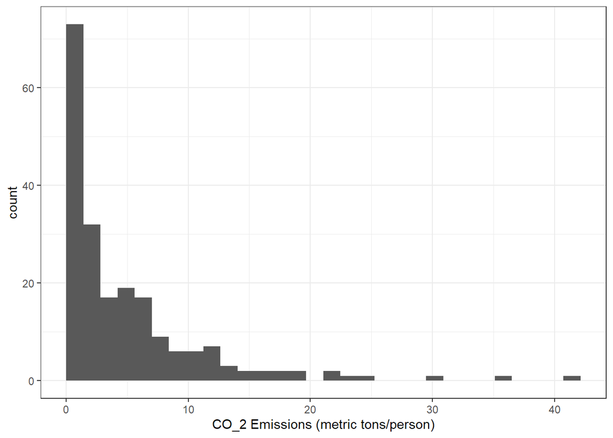

```r
ggplot(df, aes(x = X2010)) +
  geom_histogram(boundary = 0) +
  xlab("CO_2 Emissions (metric tons/person)") +
  theme_bw()
```

Find the values beyond the upper bound using the `filter` function

```r
df2 = df %>% filter(X2010 > upper_bound)

df2[,c("Country.Name","X2010")]
```

```
##            Country.Name    X2010
## 1                 Aruba 24.67053
## 2  United Arab Emirates 19.44369
## 3             Australia 17.74085
## 4               Bahrain 23.58548
## 5     Brunei Darussalam 21.10595
## 6                Canada 15.72317
## 7                Kuwait 29.89415
## 8            Luxembourg 21.63514
## 9                  Oman 15.59053
## 10                Qatar 40.74202
## 11         Saudi Arabia 18.90534
## 12  Trinidad and Tobago 36.09293
## 13        United States 17.44217
```

Can also use logical indexing

```r
df_upper = na.omit(data.frame("Country" = Country.Name[X2010 > upper_bound], "CO2" = X2010[X2010 > upper_bound]))

df_upper
```

```
##                 Country      CO2
## 1                 Aruba 24.67053
## 2  United Arab Emirates 19.44369
## 4             Australia 17.74085
## 5               Bahrain 23.58548
## 6     Brunei Darussalam 21.10595
## 7                Canada 15.72317
## 12               Kuwait 29.89415
## 13           Luxembourg 21.63514
## 17                 Oman 15.59053
## 19                Qatar 40.74202
## 20         Saudi Arabia 18.90534
## 24  Trinidad and Tobago 36.09293
## 25        United States 17.44217
```

We have 13 outliers, all of which emit the most CO$_2$.

Another way to describe where a point falls in a distribution is using the z-score. The z-score of a value $x$ is defined as $\displaystyle z = \frac{x - \bar{x}}{s}$.

### **Question 5.4**. What does it tell you about where $x$ lies in the distribution if its z-score is positive or negative?

If the z-score is positive, then $x$ is greater than the mean.

If the z-score is negative, then $x$ is less than the mean.

### **Question 5.5**. For a distribution that follows the bell-shaped Normal curve, we have a 68 − 95 − 99.7% rule that says that 68% of the distribution will be within 1 standard deviation of the mean, 95% of the distribution will be within 2 standard deviations of the mean, and 99.7% of the distribution will be within 3 standard deviations of the mean. If we try this rule with the CO$_2$ emission data in 2010 to find the middle 95% of the data, do we get reasonable results?

```r
U = mean(X2010,na.rm = TRUE) + 2*sd(X2010,na.rm = TRUE)

L = mean(X2010,na.rm = TRUE) - 2*sd(X2010,na.rm = TRUE)

print(c(L,U))
```

```
## [1] -7.64593 17.48795
```

From above we know that $\bar{x} = 4.92$ and $s$ = 6.28. So, a Normal distribution with this mean and standard deviation would have 95% of its values between

$\bar{x} - 2s = -7.65$

and

$\bar{x} + 2s = 17.49$

This is not particularly reasonable here because we know that CO$_2$ emissions are not negative. We also know from our histogram that the distribution is skewed, not symmetric like the Normal bell curve.

## 6. Graphing the distribution part 2

Another useful graph for numerical variables is the boxplot. The boxplot is a graph of the 5-number summary. A standard boxplot has a box that extends from the first quartile to the third quartile, with a line in the middle for the median. Lines are drawn from the first quartile to the minumum value and from the third quartile to the maximum value.

### **Question 6.1**. Create a boxplot of the CO$_2$ emissions in 2010 using the boxplot() function.

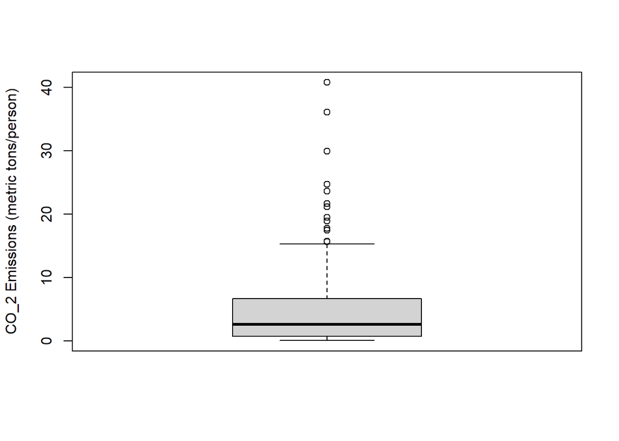

```r
boxplot(X2010, ylab = "CO_2 Emissions (metric tons/person)")
```

We can also make boxplots with `ggplot2`

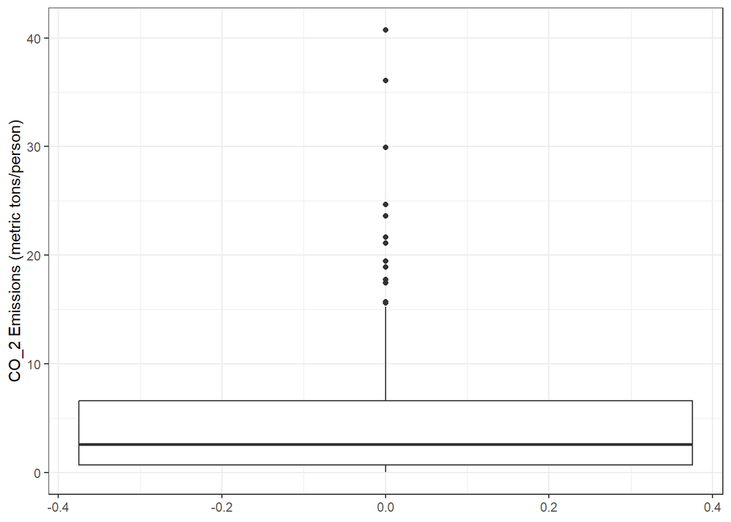

```r
ggplot(data = df,mapping = aes(y = X2010)) +
  geom_boxplot() +
  ylab("CO_2 Emissions (metric tons/person)") +
  theme_bw()
```

### **Question 6.2**. Compare the boxplot and histogram. Do they provide the same picture of the distribution? Does one provide more detail than the other?

The boxplot and the histogram provide similar pictures, but the boxplot is very limited compared to the histogram.

It is easier to see the skewness of the distribution in the histogram.

Bimodal or multimodal distributions are not easily detected using the boxplot.

Boxplots are useful for make a simple comparison of many distributions, but we can create similar graphs that provide more information. An example is a violin plot.

### **Question 6.3**. Add jittered points on top of the boxplot.

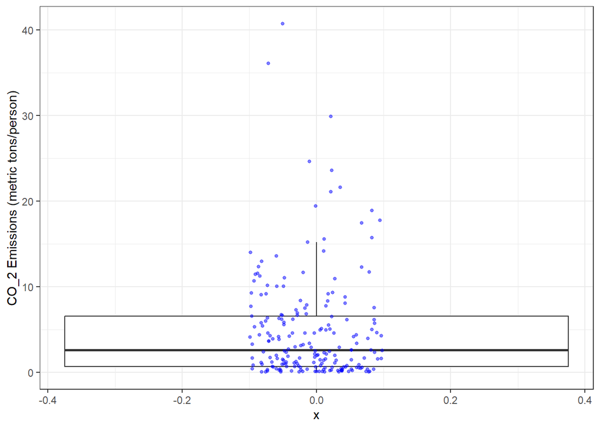

```r
ggplot(data = df,mapping = aes(x = 0, y = X2010)) +
  geom_boxplot(outlier.shape = NA) +
  geom_jitter(position=position_jitter(0.1), cex=1, alpha = 0.5, color = 'blue') +
  ylab("CO_2 Emissions (metric tons/person)") +
  theme_bw()
```

## 7. Compare the CO$_2$ distributions in 1960 and 2010.

### Question 7.1. Make comparative boxplots of the CO$_2$ emission distributions in 1960 and 2010. Discuss the differences in the distributions.

```r
df_tidy = df %>%
  pivot_longer(names_to = "year",
               values_to = "CO2",
               cols = -c(Country.Name,Country.Code,Indicator.Name,Indicator.Code))

head(df_tidy)
```

```
## # A tibble: 6 × 6
##   Country.Name Country.Code Indicator.Name            Indicator.Code year    CO2
##   <chr>        <chr>        <chr>                     <chr>          <chr> <dbl>
## 1 Aruba        ABW          CO2 emissions (metric to… EN.ATM.CO2E.PC X1960    NA
## 2 Aruba        ABW          CO2 emissions (metric to… EN.ATM.CO2E.PC X1961    NA
## 3 Aruba        ABW          CO2 emissions (metric to… EN.ATM.CO2E.PC X1962    NA
## 4 Aruba        ABW          CO2 emissions (metric to… EN.ATM.CO2E.PC X1963    NA
## 5 Aruba        ABW          CO2 emissions (metric to… EN.ATM.CO2E.PC X1964    NA
## 6 Aruba        ABW          CO2 emissions (metric to… EN.ATM.CO2E.PC X1965    NA
```

Make comparative boxplots of the CO$_2$ distributions for all years in the data set.

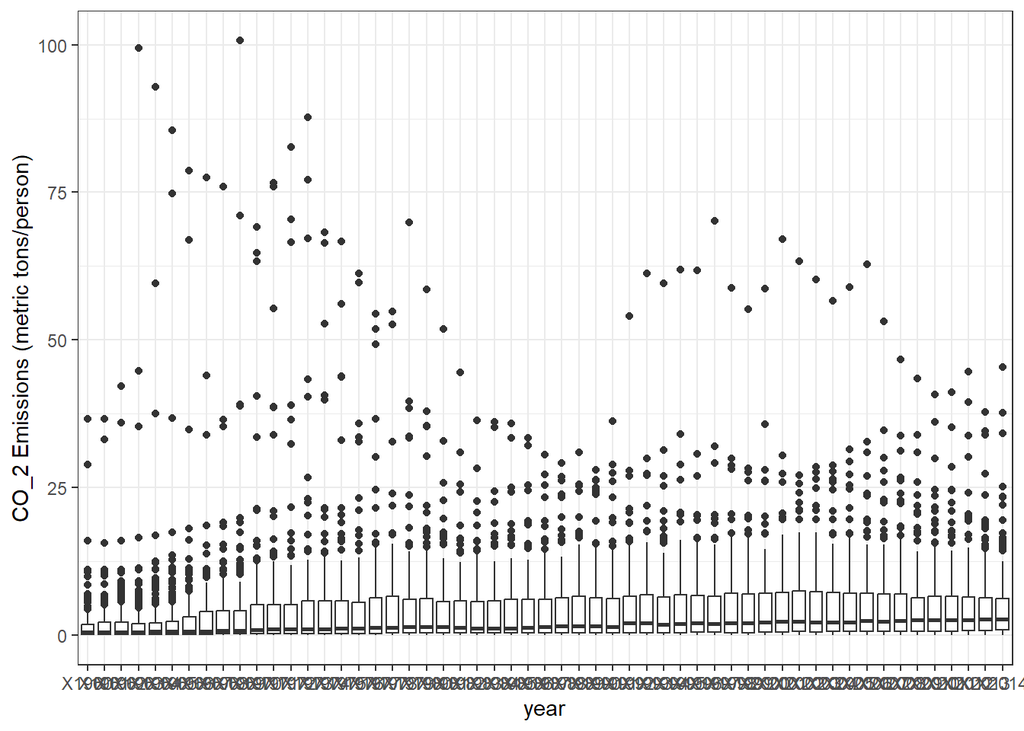

```r
ggplot(data = df_tidy, mapping = aes(x = year, y = CO2)) + geom_boxplot() + theme_bw() + labs(x = "year",y = "CO_2 Emissions (metric tons/person)")
```

Make a smaller data frame with only the years 1960 and 2010.

```r
df_tidy_small = df_tidy %>% filter(year == "X1960" | year == "X2010")

head(df_tidy_small)
```

```
## # A tibble: 6 × 6
##   Country.Name Country.Code Indicator.Name          Indicator.Code year      CO2
##   <chr>        <chr>        <chr>                   <chr>          <chr>   <dbl>
## 1 Aruba        ABW          CO2 emissions (metric … EN.ATM.CO2E.PC X1960 NA
## 2 Aruba        ABW          CO2 emissions (metric … EN.ATM.CO2E.PC X2010 24.7
## 3 Afghanistan  AFG          CO2 emissions (metric … EN.ATM.CO2E.PC X1960  0.0461
## 4 Afghanistan  AFG          CO2 emissions (metric … EN.ATM.CO2E.PC X2010  0.294
## 5 Angola       AGO          CO2 emissions (metric … EN.ATM.CO2E.PC X1960  0.0975
## 6 Angola       AGO          CO2 emissions (metric … EN.ATM.CO2E.PC X2010  1.24
```

Make comparative boxplots of the CO$_2$ distributions in 1960 and 2010.

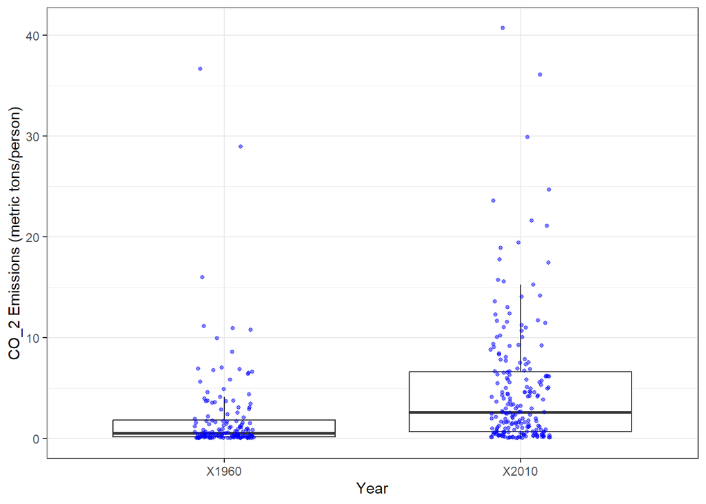

```r
ggplot(data = df_tidy_small, mapping = aes(x = year, y = CO2))  +
  geom_boxplot(outlier.shape = NA) + theme_bw() +
  geom_jitter(position=position_jitter(0.1), cex=1, alpha = 0.5, color = 'blue') +
  xlab("Year") + ylab("CO_2 Emissions (metric tons/person)")
```

CO$_2$ emissions increased from 1960 to 2010. There are many more countries with high emissions per person. This is important because populations have increased too, leading to much greater CO$_2$ emissions overall.